# statistics

*01_data_basics/07_continuous_distributions/02_normal_basic_v2*

### Background

In statistics, the word “normal” does not mean “typical”. Instead, “normal” refers to a very important continuous distribution: the [normal distribution](https://en.wikipedia.org/wiki/Normal_distribution). Normal distributions are important because random sums and random averages are approximately normal (see [central limit theorem](https://en.wikipedia.org/wiki/Central_limit_theorem)). For example, if you repeatedly roll 100 dice, taking the sum of each 100, those sums will be normally distributed (even though single rolls are [discrete-uniform](https://en.wikipedia.org/wiki/Discrete_uniform_distribution)ly distributed).

A normal distribution has a bell-shaped density curve. The center and spread of the bell are dictated by two parameters: [mean](https://en.wikipedia.org/wiki/Mean) ($\mu$) and [standard deviation](https://en.wikipedia.org/wiki/Standard_deviation) ($\sigma$). The normal density curve is defined by the following equation:
$$\text{normal density as function of x} = \frac{1}{\sigma\sqrt{2\pi}}e^{-\frac{1}{2}\left(\frac{x-\mu}{\sigma}\right)^2}$$
where $\mu$ is the mean, $\sigma$ is the standard deviation, $\pi$ is the [ratio of a circle’s circumference to its diameter](https://en.wikipedia.org/wiki/Pi), and $e$ is Euler’s number.

For the first exam, we are expected to know [the empirical rule](https://en.wikipedia.org/wiki/68%E2%80%9395%E2%80%9399.7_rule). We are going to round unconventionally, so for us it could be called the “68-96-100 rule”. It implies that in a normal distribution 68% of the measurements are within 1 standard deviation of the mean, 96% of the measurements are within 2 standard deviations of the mean, and 100% of the measurements are within 3 standard deviations of the mean.

We can visualize the “68-96-100” rule with a density curve. Notice the area of each region is shown, and you can estimate the areas by counting percentage boxes.

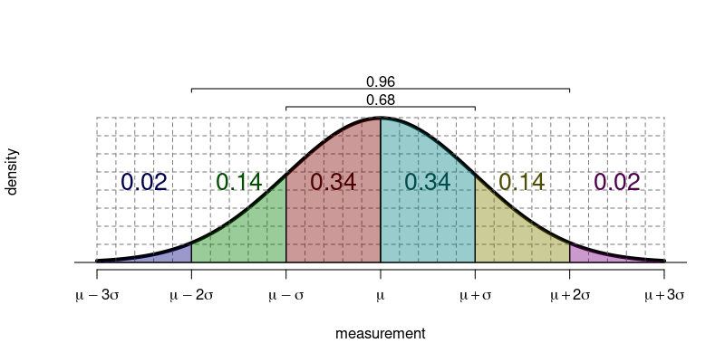

We can display our 68-96-100 rule with a spinner.

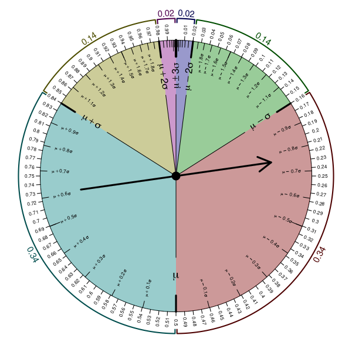

And, we can display our 68-96-100 rule with a cumulative curve. In this case, we will introduce the notation of using $z$ as the multiplier of $\sigma$. For example, if $z=-2$, then the measurement is $\mu-2\sigma$. We call $z$ the [standard score](https://en.wikipedia.org/wiki/Standard_score).

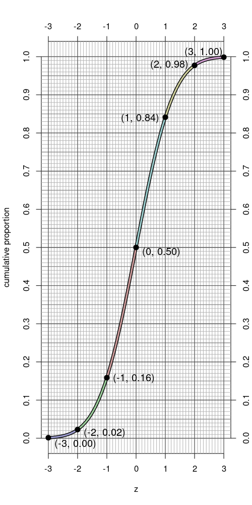

### Actual Question:

Population $X$ (with infinite individuals) has measurements that are normally distributed with mean $\mu=50$ and standard deviation $\sigma=7$. Use the empirical rule (68-96-100 rule) to answer the following questions.

1. Evaluate $\text{prop}[X<36]$.
2. Evaluate $\text{prop}[X>50]$.
3. Evaluate $\text{prop}[|X-50|<14]$.
4. Determine boundary $b$ such that $\text{prop}[X<b]=0.16$.
5. Determine boundary $b$ such that $\text{prop}[X>b]=0.16$.
6. Determine radius $r$ such that $\text{prop}[|X-50|<r]=0.68$.